## Individualized Reproducible Reports Good-bye mail merge!

### The Problem and Possible Solutions

**Problem** Need to combine information from multiple data sources to create individualized reports for hundreds, or even thousands, of recipients. Further, these reports need to be created weekly.

*In my version of the problem, my schools wanted weekly progress reports that included academic and behavior data. Some schools also wanted information on attendance, independent reading, and/or community service.*

**Mail Merge Solution** Download or collect the data in a spreadsheet, and use Microsoft Word’s Mail Merge functionality. The template is very easy to customize, but the data must be in wide format and data manipulation is often done by hand.

**Visual Basic Solution** Download or collect data in one spreadsheets. Write a VBA macro that tidies and transforms the data. This automates the process but is oftentimes very slow.

*My predecessor used this solution. It took ~20 minutes to create 400 progress reports that only included academic data.*

**R and R Markdown Solution** Write a R Markdown document that utilizes the power of R to get and clean data and the formatting options of Latex and HTML.

*Depending on the report, I retrieve data from a database* (`RODBC`)*, a GoogleSheet* (`googlesheets`) *, and even an Excel file in a shared folder* (`xlsx` or `openxlsx`) *. I replaced the VBA-generated progress report from above with a R Markdown-generated report that also included behavior information and a graph of words read, and the time to generate this report was still under a minute. Further, the entire process was automated. Rather than needing to write the results of a query to a file, then copy this data into the Excel file with the macro, I just opened the R Markdown file and clicked Knit PDF.*

### The YAML Header

The YAML header includes several of the key elements of your report template. My basic header is:

```
header-includes:
    \pagestyle{empty}
    \usepackage{wallpaper}
    \LRCornerWallPaper{1}{path/to/image}
    \URCornerWallPaper{1}{path/to/image}
    \usepackage{geometry}
    \geometry{tmargin=1.5in}
output: pdf_document
```

By default, R Markdown documents number their pages. `\pagestyle{empty}` removes page numbers from all but the first page, which I typically use as a title page with summary information.

The `wallpaper` Latex package allows you to add header and footer images in the upper-right (UR), lower-right (LR), upper-left (LR), and lower-left (LL). The number inside of the `{}` is the scaling of the image. On Windows, I experienced the problem of the image being placed directly in the corner of the page with no margin. A work-around is adding white-space to the image.

Depending on the size of your header image, you may need to adjust the margins before the content of the document starts. The `geometry` Latex package allows you to make these adjustments. [ShareLatex](https://www.sharelatex.com/learn/Page_size_and_margins#Paper_size.2C_orientation_and_margins) provides a good overview of the available options.

I always output to PDF. In general, the formatting turns out cleaner compared to generating Word documents. The Latex used in this document will not render if the output is HTML.

### Key R Code Elements

Within your R code the first step is to pull or create a list of individuals who will receive the reports. I approach this problem by pulling a list of distinct ID numbers along with their name and other basic information like adviser and grade. For clarity, I isolate the getting and cleaning of data in the first code block and put the document-creating code in the second block.

For the document-creating code, block options should include at least

`{r, echo = FALSE, results = 'asis'}`

The `asis` option allows output to be formatted as normal text rather than R output.

The first line of code provides a way to iterate through your list.

`for (i in seq_along(recipients)) {`

Inside your `for` loop, include code for displaying the information in the report. For lines of text, use `cat`. `print` should only be used with tables.

```r
library(knitr)

name <- 'R Markdown'

df <- head(mtcars[1:5])

cat(name, 'is the best!\n\n')
```

R Markdown is the best!

```r
cat(kable(df))
```

[output not shown]

```r
# Using the following will throw an error
# print(name, 'is the best!\n\n')

print(kable(df))
```

|  | mpg | cyl | disp | hp | drat |
| --- | --- | --- | --- | --- | --- |
| Mazda RX4 | 21.0 | 6 | 160 | 110 | 3.90 |
| Mazda RX4 Wag | 21.0 | 6 | 160 | 110 | 3.90 |
| Datsun 710 | 22.8 | 4 | 108 | 93 | 3.85 |
| Hornet 4 Drive | 21.4 | 6 | 258 | 110 | 3.08 |
| Hornet Sportabout | 18.7 | 8 | 360 | 175 | 3.15 |
| Valiant | 18.1 | 6 | 225 | 105 | 2.76 |

Notice that for printed lines, is it necessary to include `\n\n` to ensure line-breaks, just like when writing in typical Markdown.

Not all tables require `print`, such as `pandoc.table` from the `pander` package or `xtable`. `pandoc.table` is particularly useful if you have long text columns, because you can set the cell width.

At the bottom of your code block but inside your `for` loop, include the page break. `cat('\n\n\\pagebreak\n')`

This is the first example of needing to include `\\`. Like with regular expressions, without the extra `\`, R will think `\p` as an escape character.

### Other Useful Code Elements

Three other building blocks I use often are the section header

`cat('\\section*{Name of section}\n\n')`

centered text

`cat('\\centerline{Centered Text}\n\n')`

and a horizontal line

`cat('\n\n------\n\n')`.

If you have multiple graphs and would like to display them side-by-side, rather than the default one graph per line, I suggest `grid.arrange` from `gridExtra`. It is also possible to group more than two graphs. This allows you to set the `fig.height` and `fig.width` for the entire grouping, helpful if you need to fit all the graphs on a single page.

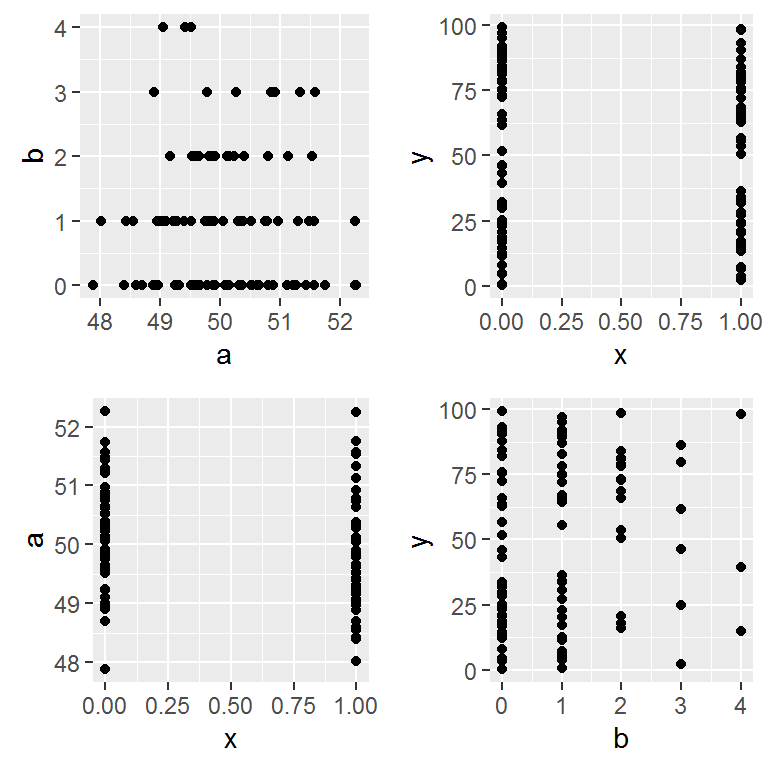

```r
library(ggplot2)
library(gridExtra)

a <- rnorm(100, 50)
b <- rpois(100, 1)
x <- rbinom(100, 1, 0.5)
y <- runif(100, 0, 100)

p1 <- qplot(a, b)
p2 <- qplot(x, y)
p3 <- qplot(x, a)
p4 <- qplot(b, y)

grid.arrange(p1, p2, p3, p4)
```